# ACMG/AMP Classifier Benchmark

GermlineQC rule engine vs ClinVar consensus (>= 2 review stars), chr20

## What was tested

`bin/acmg_classify.py` applies the ACMG/AMP criteria that can be evaluated from data (PVS1, PS1, PM2, PM4, PM5, PP3, BA1, BS1, BP4, BP7) and combines them with the ClinGen SVI point system. Evidence: gnomAD v4.1 exomes and genomes, REVEL (ClinGen-calibrated thresholds), ClinGen haploinsufficiency scores and other ClinVar pathogenic missense variants (PS1/PM5).

The truth set is every chr20 ClinVar variant whose classification has at least two review stars (multiple submitters with no conflicts, expert panel or practice guideline). A variant’s own ClinVar record is never used as evidence for it. Thresholds were fixed before the benchmark was run (`assets/acmg_rules.yaml`).

## Headline numbers

| ClinVar class | Variants | Same direction | VUS | Opposite direction |
| --- | --- | --- | --- | --- |
| P/LP | 1,391 | 36.7% (34.2%-39.3%) | 63.1% | 0.14% (0.04%-0.52%) |
| B/LB | 8,080 | 75.5% (74.5%-76.4%) | 24.5% | 0.00% (0.00%-0.05%) |

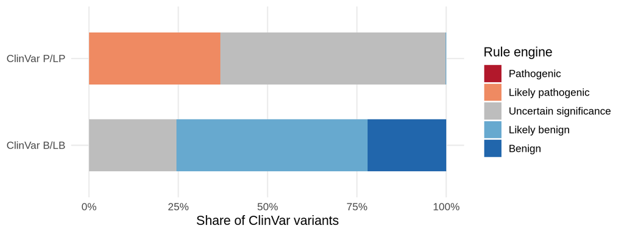

## By variant consequence

| Consequence | ClinVar | N | Same direction | VUS | Opposite |
| --- | --- | --- | --- | --- | --- |
| in-frame / stop-loss | P/LP | 9 | 0.0% | 100.0% | 0.00% |
| in-frame / stop-loss | B/LB | 18 | 66.7% | 33.3% | 0.00% |
| intronic / UTR / flanking | P/LP | 14 | 0.0% | 100.0% | 0.00% |
| intronic / UTR / flanking | B/LB | 2386 | 67.4% | 32.6% | 0.00% |
| missense | P/LP | 470 | 24.3% | 75.3% | 0.43% |
| missense | B/LB | 1148 | 84.7% | 15.3% | 0.00% |
| null (LoF) | P/LP | 885 | 44.9% | 55.1% | 0.00% |
| null (LoF) | B/LB | 22 | 72.7% | 27.3% | 0.00% |
| other / unannotated | P/LP | 2 | 0.0% | 100.0% | 0.00% |
| other / unannotated | B/LB | 2 | 0.0% | 100.0% | 0.00% |
| splice region | P/LP | 11 | 0.0% | 100.0% | 0.00% |
| splice region | B/LB | 346 | 39.6% | 60.4% | 0.00% |
| synonymous | B/LB | 4158 | 80.6% | 19.4% | 0.00% |

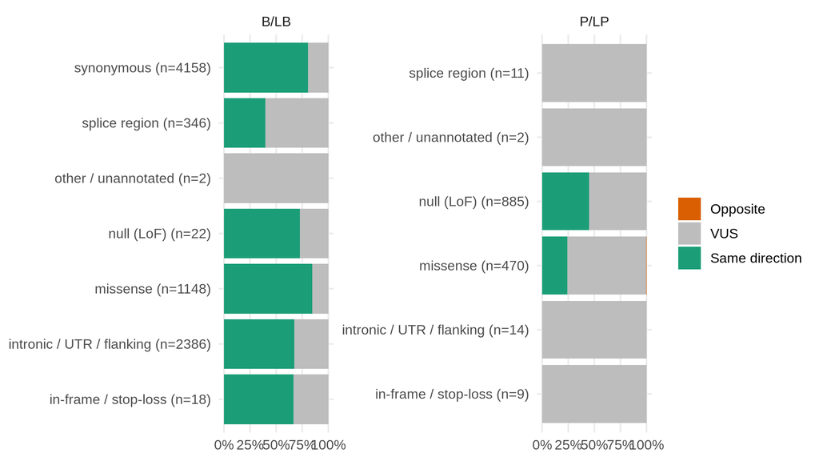

## Which criteria fired

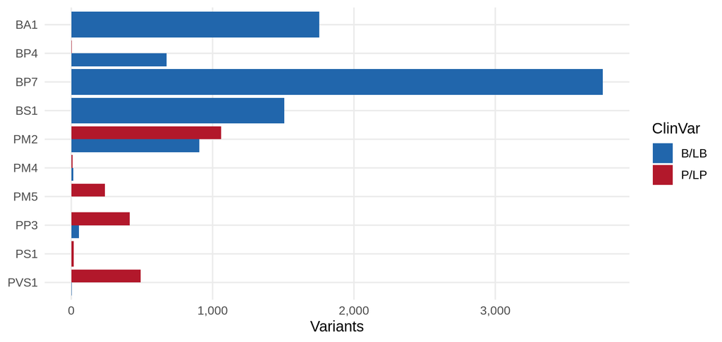

## Opposite-direction calls

These are the errors that matter most, and each one is listed for review.

| gene | hgvs_p | consequence | gnomad_faf | revel | criteria | predicted | clinvar |
| --- | --- | --- | --- | --- | --- | --- | --- |
| CFAP61 | p.Arg552Cys | missense_variant | 0.0005007 | 0.118 | BP4_Moderate | Likely benign | P/LP |
| HNF4A | p.Pro459Leu | missense_variant | NA | 0.164 | PM2_Supporting,BP4_Moderate | Likely benign | P/LP |

## Interpretation and limits

- Most criteria that need case-level or functional data (segregation, de novo status, functional studies, phenotype specificity, hotspot domains) cannot be automated, so many truly pathogenic variants stop at VUS. That is the expected, conservative failure mode. A rule engine like this prioritises variants for a scientist’s review and does not replace that review.
- ClinVar submitters also use gnomAD frequencies, so population-based criteria are not fully independent of the truth labels. Benign concordance is therefore an upper bound.
- No splicing predictor (e.g. SpliceAI) is included, so PP3/BP4 are not applied to non-missense variants and BP7 is applied to synonymous variants without a splicing check.
- The most severe SnpEff consequence across protein-coding transcripts is used, not the MANE Select transcript.